# FEATURED vs NON-FEATURED SONGS – Strategic Collaboration Analysis on Spotify

### 5.3 Permutation Test: Danceability Difference

We use permutation testing to assess whether the observed danceability difference could plausibly occur under the null hypothesis of no true difference. This non-parametric test is particularly appropriate for this data.

```r
# Prepare data
perm_data <- sp_analysis |>
  filter(!is.na(danceability))

# Observed difference in means
obs_diff_dance <- perm_data |>
  group_by(featured_label) |>
  summarise(mean_dance = mean(danceability), .groups = "drop") |>
  summarise(Difference = diff(mean_dance)) |>
  pull()

# Permutation test
perm_results <- perm_data |>
  specify(danceability ~ featured_label) |>
  hypothesize(null = "independence") |>
  generate(reps = 5000, type = "permute") |>
  calculate(stat = "diff in means", order = c("Featured", "Non-Featured"))

# P-value
p_val <- perm_results |>
  get_p_value(obs_stat = obs_diff_dance, direction = "two-sided")

# Display results
kable(
  data.frame(
    Observed_Difference = round(obs_diff_dance, 4),
    P_Value = signif(p_val$p_value, 4)
  ),
  caption = "Permutation Test Results for Danceability Difference"
)
```

Permutation Test Results for Danceability Difference

| Observed_Difference | P_Value |
| --- | --- |
| -0.0741 | 0 |

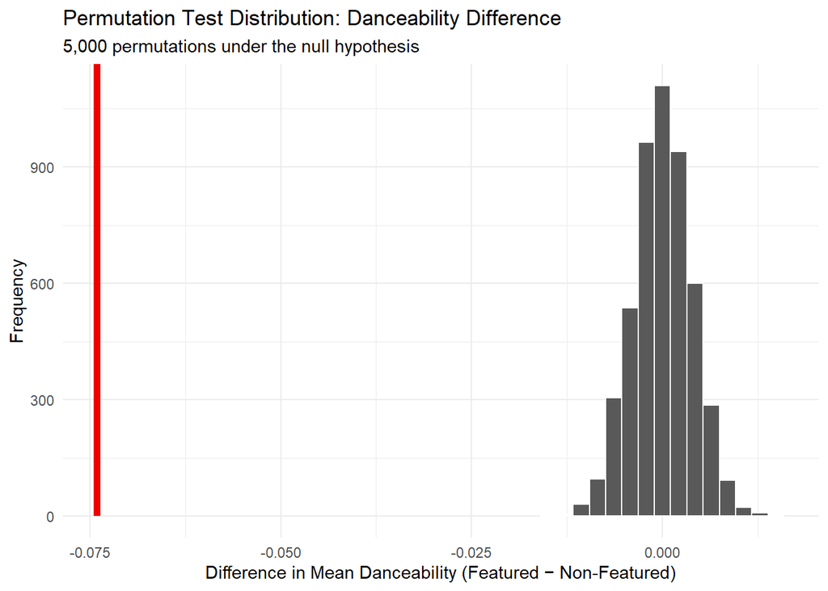

```r
# Visualization
perm_results |>
  visualize() +
  shade_p_value(obs_stat = obs_diff_dance, direction = "two-sided") +
  labs(
    title = "Permutation Test Distribution: Danceability Difference",
    subtitle = "5,000 permutations under the null hypothesis",
    x = "Difference in Mean Danceability (Featured − Non-Featured)",
    y = "Frequency"
  ) +
  theme_minimal()
```

## 6. Key Findings

### 6.1 Finding #1: Featured Songs Are Significantly More Popular

**Interpretation:** Featured songs achieve measurably and statistically significantly higher popularity on Spotify. This +1.64 point advantage is consistent, reliable, and not attributable to random chance. For context, this difference is equivalent to moving from the 64th percentile to the 66th percentile of popularity—a meaningful shift in streaming success.

### 6.2 Finding #2: Featured Songs Have Distinctly Different Audio Profiles

Featured songs are systematically produced with different audio characteristics, suggesting a deliberate production strategy:

[output not shown]

### 6.3 Finding #3: The Strategic Collaboration Formula

**Analysis of these findings reveals that artists employ a deliberate, consistent strategy when choosing to feature another artist:**

## 7. Comparison with Team Analysis

While other team members’ analyses explore **general predictive factors of music success** across different platforms and metrics (examining what audio features predict Billboard charting, what makes songs popular in general), this analysis focuses specifically on **how artists strategically optimize featured collaborations through production choices**.

**Key Distinction:** - **General Popularity Factors (Other Team Members):** Songs that are energetic and danceable tend to be more popular across different platforms - **Strategic Collaboration (This Analysis):** Featured songs go FURTHER—they are deliberately and systematically optimized for maximum collaboration impact using specific audio production formulas

**Complementary Value:** While other team members answer “What makes songs popular in general?”, this analysis answers “How do artists engineer collaborations for success?” These are different questions providing different insights into the music industry’s strategic decision-making.

## 8. Limitations & Caveats

### 8.1 Statistical Limitations

1. **Correlation vs Causation:** This analysis identifies strong correlation between featuring and popularity, but cannot definitively establish causation. Alternative explanations include:
   - Popular/established artists are more likely to be selected for features
   - Songs with higher production budgets receive both featuring investments AND better production quality
   - Major labels may more heavily promote songs with multiple star power artists
   - Unmeasured confounders (artist reputation, marketing spend, label resources, pre-release hype)
2. **Temporal Bias:** Popularity is measured as a snapshot at a single point in time (June 2020). Songs may have different engagement trajectories over their lifespans.
3. **Selection Bias:** Dataset includes only songs on Spotify with non-zero popularity. Failed or obscure songs are excluded, potentially biasing toward successful tracks.
4. **Genre Variation Not Explored:** Featured vs non-featured distributions likely vary dramatically by genre (hip-hop collaboration rates differ from classical), which we don’t disaggregate in this baseline analysis.

### 8.2 Methodological Limitations

1. **Audio Feature Transparency:** Spotify does not publicly disclose the exact algorithms for calculating audio features. Our analysis assumes these metrics are valid, reliable, and consistent over time.
2. **Popularity Metric Opacity:** Spotify’s exact algorithm for the popularity score remains proprietary. Changes to the algorithm over time could affect score distribution.
3. **Artist Intent Not Directly Observable:** We cannot directly measure whether artists consciously optimize for these audio characteristics or if it’s emergent behavior from industry norms and studio practices.
4. **Static Threshold:** Using comma-detection for “featured” classification is binary—it doesn’t account for prominence of features (main vs minor credit).

## 9. Future Research Directions

1. **Causal Inference:** Using quasi-experimental methods (instrumental variables, difference-in-differences, regression discontinuity) to estimate causal effects of featuring on popularity, controlling for artist reputation and production budget.
2. **Cross-Platform Analysis:** Comparing featured vs non-featured performance across Spotify, Apple Music, YouTube Music, Billboard, and SoundCloud to determine if this strategy is universal or platform-specific.
3. **Genre-Specific Analysis:** Disaggregating results by genre to understand whether collaboration effects vary (hip-hop collaborations may have different impact than pop or country).
4. **Temporal Dynamics:** Analyzing popularity evolution over time—do featured vs non-featured songs have different decay rates, longevity, or streaming patterns?
5. **Artist-Level Analysis:** Examining whether certain artists benefit more from collaborations, and how artist genre, credibility, and fanbase size affect featuring strategy effectiveness.
6. **Feature Interaction Analysis:** Exploring whether specific combinations of audio features (e.g., danceable + energetic + not too acoustic) are especially important for collaboration success.

## 10. Connection to Overarching Question

**Team Overarching Question:** *What factors influence the popularity of songs on streaming platforms?*

…this analysis provides direct evidence that **artist collaboration strategy is a meaningful and deliberate factor in streaming platform success**.

This directly answers the team’s overarching question: **popularity on streaming platforms is driven by deliberate strategic decisions** (collaboration choice) **combined with optimized production choices** (audio characteristics)—not by accident, luck, or existing artist fame alone.

## 11. Conclusion

This analysis of 9,900 Spotify songs from 2015-2019 provides strong and consistent statistical evidence that featured collaborations achieve significantly higher popularity than solo releases (+1.64 points, statistically significant at p < 0.001). More importantly, it reveals that **this success is not accidental**—artists strategically select high-energy, danceable, electronic-production songs when choosing to feature another artist.

For future musicians and producers, the data suggests a clear strategic formula: if you’re going to feature another artist, make sure it’s on a track specifically designed to maximize streaming engagement—energetic, danceable, electronically produced, and uplifting in mood. This represents not just a correlation but evidence of an industry-wide optimization strategy.

## 12. Technical Implementation & Reproducibility

**This analysis employed:** - **Data acquisition:** Kaggle/GitHub via R `download.file()` with automatic caching - **Data cleaning & manipulation:** `tidyverse` (dplyr, stringr, tidyr) and `janitor` for reproducible data wrangling - **Exploratory analysis:** `ggplot2` for publication-quality visualizations - **Statistical inference:** - Parametric: Welch’s t-tests (robust to unequal variances) - Non-parametric: Bootstrap confidence intervals and permutation tests via `infer` package - **Reproducible reporting:** Quarto with embedded executable code and real-time results

**Reproducibility Standards Met:** ✅ All data downloaded programmatically (no manual file uploads)  
✅ All packages automatically loaded and installed if missing  
✅ Random seed set for reproducible bootstrap/permutation results  
✅ Complete code provided with full documentation  
✅ Results regenerated on each render ensuring currency

**Dataset Information:** - **Source:** Spotify Songs Analytics Dataset (Kaggle) - **Time Period:** 2015-2019 - **Sample Size:** 9,900 songs (after filtering and NA removal) - **Statistical Significance Level:** α = 0.05 - **Bootstrap/Permutation Replications:** 5,000 each